# Risk Factor Analysis

## Outcome Variable

**Outcome Variable:** stunted

## Predictor Variables

**Intervention Variable:** perdiar24

**Adjustment Set:**

- arm
- sex
- meducyrs
- hhwealth_quart
- hfoodsec
- hdlvry
- W_birthwt
- W_birthlen
- W_nrooms
- month
- brthmon
- impfloor
- impsan
- safeh20
- delta_meducyrs
- delta_hhwealth_quart
- delta_hfoodsec
- delta_hdlvry
- delta_W_birthwt
- delta_W_birthlen
- delta_W_nrooms
- delta_month
- delta_brthmon
- delta_impfloor
- delta_impsan
- delta_safeh20

## Stratifying Variables

The analysis was stratified on these variable(s):

- agecat
- studyid
- country

## Data Summary

| agecat | studyid | country | perdiar24 | stunted | n_cell | n |
| --- | --- | --- | --- | --- | --- | --- |
| Birth | ki0047075b-MAL-ED | BANGLADESH | Q1 | 0 | 23 | 257 |
| Birth | ki0047075b-MAL-ED | BANGLADESH | Q1 | 1 | 7 | 257 |
| Birth | ki0047075b-MAL-ED | BANGLADESH | Q2 | 0 | 41 | 257 |
| Birth | ki0047075b-MAL-ED | BANGLADESH | Q2 | 1 | 10 | 257 |
| Birth | ki0047075b-MAL-ED | BANGLADESH | Q3 | 0 | 85 | 257 |
| Birth | ki0047075b-MAL-ED | BANGLADESH | Q3 | 1 | 10 | 257 |
| Birth | ki0047075b-MAL-ED | BANGLADESH | Q4 | 0 | 61 | 257 |
| Birth | ki0047075b-MAL-ED | BANGLADESH | Q4 | 1 | 20 | 257 |
| 6 months | ki0047075b-MAL-ED | BANGLADESH | Q1 | 0 | 9 | 241 |
| 6 months | ki0047075b-MAL-ED | BANGLADESH | Q1 | 1 | 5 | 241 |
| 6 months | ki0047075b-MAL-ED | BANGLADESH | Q2 | 0 | 41 | 241 |
| 6 months | ki0047075b-MAL-ED | BANGLADESH | Q2 | 1 | 8 | 241 |
| 6 months | ki0047075b-MAL-ED | BANGLADESH | Q3 | 0 | 82 | 241 |
| 6 months | ki0047075b-MAL-ED | BANGLADESH | Q3 | 1 | 14 | 241 |
| 6 months | ki0047075b-MAL-ED | BANGLADESH | Q4 | 0 | 64 | 241 |
| 6 months | ki0047075b-MAL-ED | BANGLADESH | Q4 | 1 | 18 | 241 |
| 24 months | ki0047075b-MAL-ED | BANGLADESH | Q1 | 0 | 7 | 212 |
| 24 months | ki0047075b-MAL-ED | BANGLADESH | Q1 | 1 | 7 | 212 |
| 24 months | ki0047075b-MAL-ED | BANGLADESH | Q2 | 0 | 27 | 212 |
| 24 months | ki0047075b-MAL-ED | BANGLADESH | Q2 | 1 | 15 | 212 |
| 24 months | ki0047075b-MAL-ED | BANGLADESH | Q3 | 0 | 47 | 212 |
| 24 months | ki0047075b-MAL-ED | BANGLADESH | Q3 | 1 | 41 | 212 |
| 24 months | ki0047075b-MAL-ED | BANGLADESH | Q4 | 0 | 33 | 212 |
| 24 months | ki0047075b-MAL-ED | BANGLADESH | Q4 | 1 | 35 | 212 |
| Birth | ki0047075b-MAL-ED | BRAZIL | Q1 | 0 | 111 | 191 |
| Birth | ki0047075b-MAL-ED | BRAZIL | Q1 | 1 | 12 | 191 |
| Birth | ki0047075b-MAL-ED | BRAZIL | Q2 | 0 | 45 | 191 |
| Birth | ki0047075b-MAL-ED | BRAZIL | Q2 | 1 | 8 | 191 |
| Birth | ki0047075b-MAL-ED | BRAZIL | Q3 | 0 | 13 | 191 |
| Birth | ki0047075b-MAL-ED | BRAZIL | Q3 | 1 | 1 | 191 |

[output cut: 356 more lines]

The following strata were considered:

- agecat: 24 months, studyid: ki0047075b-MAL-ED, country: BANGLADESH
- agecat: 24 months, studyid: ki0047075b-MAL-ED, country: BRAZIL
- agecat: 24 months, studyid: ki0047075b-MAL-ED, country: INDIA
- agecat: 24 months, studyid: ki0047075b-MAL-ED, country: NEPAL
- agecat: 24 months, studyid: ki0047075b-MAL-ED, country: PERU
- agecat: 24 months, studyid: ki0047075b-MAL-ED, country: SOUTH AFRICA
- agecat: 24 months, studyid: ki0047075b-MAL-ED, country: TANZANIA, UNITED REPUBLIC OF
- agecat: 24 months, studyid: ki1017093-NIH-Birth, country: BANGLADESH
- agecat: 24 months, studyid: ki1017093b-PROVIDE, country: BANGLADESH
- agecat: 24 months, studyid: ki1017093c-NIH-Crypto, country: BANGLADESH
- agecat: 24 months, studyid: ki1114097-CMIN, country: BANGLADESH
- agecat: 24 months, studyid: ki1114097-CMIN, country: GUINEA-BISSAU
- agecat: 24 months, studyid: ki1114097-CMIN, country: PERU
- agecat: 24 months, studyid: ki1114097-CONTENT, country: PERU
- agecat: 24 months, studyid: kiGH5241-JiVitA-4, country: BANGLADESH
- agecat: 6 months, studyid: ki0047075b-MAL-ED, country: BANGLADESH
- agecat: 6 months, studyid: ki0047075b-MAL-ED, country: BRAZIL
- agecat: 6 months, studyid: ki0047075b-MAL-ED, country: INDIA
- agecat: 6 months, studyid: ki0047075b-MAL-ED, country: NEPAL
- agecat: 6 months, studyid: ki0047075b-MAL-ED, country: PERU
- agecat: 6 months, studyid: ki0047075b-MAL-ED, country: SOUTH AFRICA
- agecat: 6 months, studyid: ki0047075b-MAL-ED, country: TANZANIA, UNITED REPUBLIC OF
- agecat: 6 months, studyid: ki1000109-EE, country: PAKISTAN
- agecat: 6 months, studyid: ki1000109-ResPak, country: PAKISTAN
- agecat: 6 months, studyid: ki1000304b-SAS-FoodSuppl, country: INDIA
- agecat: 6 months, studyid: ki1017093-NIH-Birth, country: BANGLADESH
- agecat: 6 months, studyid: ki1017093b-PROVIDE, country: BANGLADESH
- agecat: 6 months, studyid: ki1017093c-NIH-Crypto, country: BANGLADESH
- agecat: 6 months, studyid: ki1112895-Guatemala BSC, country: GUATEMALA
- agecat: 6 months, studyid: ki1114097-CMIN, country: BANGLADESH
- agecat: 6 months, studyid: ki1114097-CMIN, country: BRAZIL
- agecat: 6 months, studyid: ki1114097-CMIN, country: GUINEA-BISSAU
- agecat: 6 months, studyid: ki1114097-CMIN, country: PERU
- agecat: 6 months, studyid: ki1114097-CONTENT, country: PERU
- agecat: 6 months, studyid: kiGH5241-JiVitA-4, country: BANGLADESH
- agecat: Birth, studyid: ki0047075b-MAL-ED, country: BANGLADESH
- agecat: Birth, studyid: ki0047075b-MAL-ED, country: BRAZIL
- agecat: Birth, studyid: ki0047075b-MAL-ED, country: INDIA
- agecat: Birth, studyid: ki0047075b-MAL-ED, country: NEPAL
- agecat: Birth, studyid: ki0047075b-MAL-ED, country: PERU
- agecat: Birth, studyid: ki0047075b-MAL-ED, country: SOUTH AFRICA
- agecat: Birth, studyid: ki0047075b-MAL-ED, country: TANZANIA, UNITED REPUBLIC OF
- agecat: Birth, studyid: ki1000109-EE, country: PAKISTAN
- agecat: Birth, studyid: ki1000109-ResPak, country: PAKISTAN
- agecat: Birth, studyid: ki1017093-NIH-Birth, country: BANGLADESH
- agecat: Birth, studyid: ki1017093c-NIH-Crypto, country: BANGLADESH
- agecat: Birth, studyid: ki1114097-CMIN, country: BANGLADESH
- agecat: Birth, studyid: ki1114097-CMIN, country: BRAZIL
- agecat: Birth, studyid: ki1114097-CMIN, country: PERU
- agecat: Birth, studyid: ki1114097-CONTENT, country: PERU
- agecat: Birth, studyid: kiGH5241-JiVitA-4, country: BANGLADESH

### Dropped Strata

Some strata were dropped due to rare outcomes:

- agecat: Birth, studyid: ki0047075b-MAL-ED, country: BRAZIL
- agecat: 6 months, studyid: ki0047075b-MAL-ED, country: BRAZIL
- agecat: 24 months, studyid: ki0047075b-MAL-ED, country: BRAZIL
- agecat: 6 months, studyid: ki0047075b-MAL-ED, country: NEPAL
- agecat: 24 months, studyid: ki0047075b-MAL-ED, country: NEPAL
- agecat: Birth, studyid: ki0047075b-MAL-ED, country: NEPAL
- agecat: Birth, studyid: ki0047075b-MAL-ED, country: PERU
- agecat: 6 months, studyid: ki0047075b-MAL-ED, country: PERU
- agecat: 24 months, studyid: ki0047075b-MAL-ED, country: PERU
- agecat: Birth, studyid: ki0047075b-MAL-ED, country: SOUTH AFRICA
- agecat: 6 months, studyid: ki0047075b-MAL-ED, country: SOUTH AFRICA
- agecat: 24 months, studyid: ki0047075b-MAL-ED, country: SOUTH AFRICA
- agecat: Birth, studyid: ki0047075b-MAL-ED, country: TANZANIA, UNITED REPUBLIC OF
- agecat: Birth, studyid: ki1000109-EE, country: PAKISTAN
- agecat: Birth, studyid: ki1000109-ResPak, country: PAKISTAN
- agecat: 6 months, studyid: ki1000109-ResPak, country: PAKISTAN
- agecat: 6 months, studyid: ki1000304b-SAS-FoodSuppl, country: INDIA
- agecat: 24 months, studyid: ki1017093-NIH-Birth, country: BANGLADESH
- agecat: Birth, studyid: ki1017093-NIH-Birth, country: BANGLADESH
- agecat: Birth, studyid: ki1017093c-NIH-Crypto, country: BANGLADESH
- agecat: 6 months, studyid: ki1114097-CMIN, country: BANGLADESH
- agecat: 24 months, studyid: ki1114097-CMIN, country: BANGLADESH
- agecat: Birth, studyid: ki1114097-CMIN, country: BANGLADESH
- agecat: Birth, studyid: ki1114097-CMIN, country: BRAZIL
- agecat: 6 months, studyid: ki1114097-CMIN, country: BRAZIL
- agecat: 6 months, studyid: ki1114097-CMIN, country: GUINEA-BISSAU
- agecat: Birth, studyid: ki1114097-CMIN, country: PERU
- agecat: 6 months, studyid: ki1114097-CONTENT, country: PERU
- agecat: 24 months, studyid: ki1114097-CONTENT, country: PERU
- agecat: Birth, studyid: ki1114097-CONTENT, country: PERU

## Methods Detail

We’re interested in the causal parameters $E[Y_a]$ for all values of $a \in \mathcal{A}$. These parameters represent the mean outcome if, possibly contrary to fact, we intervened to set all units to have $A=a$. Under the randomization and positivity assumptions, these are identified by the statistical parameters $\psi_a=E_W[E_{Y|A,W}(Y|A=a,W)]$. In addition, we’re interested in the mean of $Y$, $E[Y]$ under no intervention (the observed mean). We will estimate these parameters by using SuperLearner to fit the relevant likelihood factors – $E_{Y|A,W}(Y|A=a,W)$ and $p(A=a|W)$, and then updating our likelihood fit using a joint TMLE.

For unadjusted analyses ($W=\{\}$), initial likelihoods were estimated using Lrnr_glm to estimate the simple $E(Y|A)$ and Lrnr_mean to estimate $p(A)$. For adjusted analyses, a small library containing Lrnr_glmnet, Lrnr_xgboost, and Lrnr_mean was used.

Having estimated these parameters, we will then use the delta method to estimate relative risks and attributable risks relative to a prespecified baseline level of $A$.

# Results Detail

## Results Plots

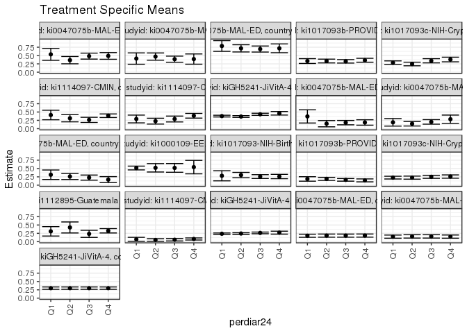

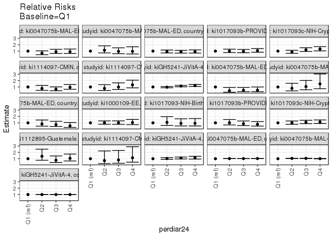

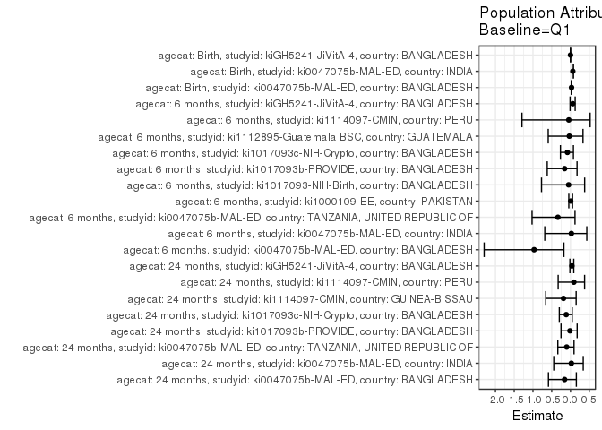

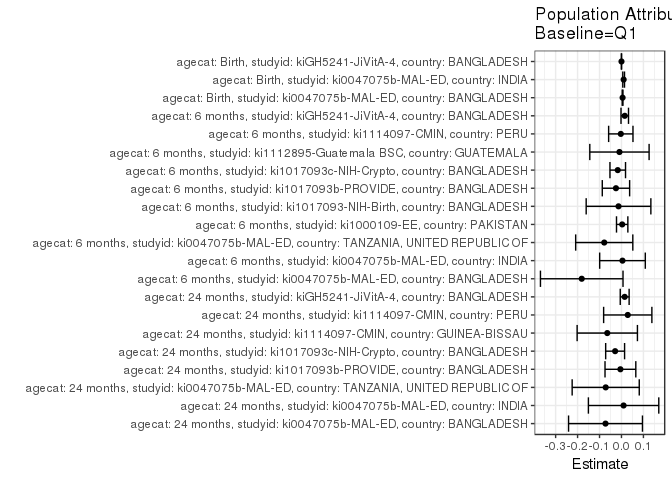

## Results Table

### Parameter: TSM

| agecat | studyid | country | intervention_level | baseline_level | estimate | ci_lower | ci_upper |
| --- | --- | --- | --- | --- | --- | --- | --- |
| Birth | ki0047075b-MAL-ED | BANGLADESH | Q1 | NA | 0.1777962 | 0.1315850 | 0.2240074 |
| Birth | ki0047075b-MAL-ED | BANGLADESH | Q2 | NA | 0.1812265 | 0.1342653 | 0.2281877 |
| Birth | ki0047075b-MAL-ED | BANGLADESH | Q3 | NA | 0.1809076 | 0.1340059 | 0.2278093 |
| Birth | ki0047075b-MAL-ED | BANGLADESH | Q4 | NA | 0.1823884 | 0.1351049 | 0.2296720 |
| Birth | ki0047075b-MAL-ED | INDIA | Q1 | NA | 0.1503067 | 0.1027182 | 0.1978952 |
| Birth | ki0047075b-MAL-ED | INDIA | Q2 | NA | 0.1576488 | 0.1080029 | 0.2072946 |
| Birth | ki0047075b-MAL-ED | INDIA | Q3 | NA | 0.1577715 | 0.1080694 | 0.2074735 |
| Birth | ki0047075b-MAL-ED | INDIA | Q4 | NA | 0.1515569 | 0.1032993 | 0.1998144 |
| Birth | kiGH5241-JiVitA-4 | BANGLADESH | Q1 | NA | 0.3004339 | 0.2648612 | 0.3360066 |
| Birth | kiGH5241-JiVitA-4 | BANGLADESH | Q2 | NA | 0.3005237 | 0.2649574 | 0.3360900 |
| Birth | kiGH5241-JiVitA-4 | BANGLADESH | Q3 | NA | 0.3005082 | 0.2649378 | 0.3360786 |
| Birth | kiGH5241-JiVitA-4 | BANGLADESH | Q4 | NA | 0.3004911 | 0.2649341 | 0.3360482 |
| 6 months | ki0047075b-MAL-ED | BANGLADESH | Q1 | NA | 0.3678037 | 0.1692760 | 0.5663314 |
| 6 months | ki0047075b-MAL-ED | BANGLADESH | Q2 | NA | 0.1492997 | 0.0555208 | 0.2430785 |
| 6 months | ki0047075b-MAL-ED | BANGLADESH | Q3 | NA | 0.1807264 | 0.1154677 | 0.2459852 |
| 6 months | ki0047075b-MAL-ED | BANGLADESH | Q4 | NA | 0.1861421 | 0.1049840 | 0.2673002 |
| 6 months | ki0047075b-MAL-ED | INDIA | Q1 | NA | 0.1903201 | 0.0771295 | 0.3035107 |
| 6 months | ki0047075b-MAL-ED | INDIA | Q2 | NA | 0.1484068 | 0.0802806 | 0.2165331 |
| 6 months | ki0047075b-MAL-ED | INDIA | Q3 | NA | 0.2036029 | 0.1356703 | 0.2715356 |
| 6 months | ki0047075b-MAL-ED | INDIA | Q4 | NA | 0.2837961 | 0.1590789 | 0.4085133 |
| 6 months | ki0047075b-MAL-ED | TANZANIA, UNITED REPUBLIC OF | Q1 | NA | 0.3133153 | 0.1707001 | 0.4559306 |
| 6 months | ki0047075b-MAL-ED | TANZANIA, UNITED REPUBLIC OF | Q2 | NA | 0.2604472 | 0.1690832 | 0.3518112 |
| 6 months | ki0047075b-MAL-ED | TANZANIA, UNITED REPUBLIC OF | Q3 | NA | 0.2271490 | 0.1506491 | 0.3036488 |
| 6 months | ki0047075b-MAL-ED | TANZANIA, UNITED REPUBLIC OF | Q4 | NA | 0.1663827 | 0.0766875 | 0.2560780 |
| 6 months | ki1000109-EE | PAKISTAN | Q1 | NA | 0.5156101 | 0.4587560 | 0.5724642 |
| 6 months | ki1000109-EE | PAKISTAN | Q2 | NA | 0.5212083 | 0.3952574 | 0.6471592 |
| 6 months | ki1000109-EE | PAKISTAN | Q3 | NA | 0.5181892 | 0.3871160 | 0.6492624 |
| 6 months | ki1000109-EE | PAKISTAN | Q4 | NA | 0.5422482 | 0.3399811 | 0.7445153 |
| 6 months | ki1017093-NIH-Birth | BANGLADESH | Q1 | NA | 0.2816254 | 0.1298565 | 0.4333944 |
| 6 months | ki1017093-NIH-Birth | BANGLADESH | Q2 | NA | 0.3037393 | 0.2237762 | 0.3837024 |

[output cut: 54 more lines]

### Parameter: E(Y)

| agecat | studyid | country | intervention_level | baseline_level | estimate | ci_lower | ci_upper |
| --- | --- | --- | --- | --- | --- | --- | --- |
| Birth | ki0047075b-MAL-ED | BANGLADESH | NA | NA | 0.1828794 | 0.1355257 | 0.2302330 |
| Birth | ki0047075b-MAL-ED | INDIA | NA | NA | 0.1601942 | 0.1099849 | 0.2104035 |
| Birth | kiGH5241-JiVitA-4 | BANGLADESH | NA | NA | 0.3004866 | 0.2649179 | 0.3360553 |
| 6 months | ki0047075b-MAL-ED | BANGLADESH | NA | NA | 0.1867220 | 0.1374205 | 0.2360234 |
| 6 months | ki0047075b-MAL-ED | INDIA | NA | NA | 0.1949153 | 0.1442678 | 0.2455627 |
| 6 months | ki0047075b-MAL-ED | TANZANIA, UNITED REPUBLIC OF | NA | NA | 0.2348178 | 0.1818480 | 0.2877876 |
| 6 months | ki1000109-EE | PAKISTAN | NA | NA | 0.5188172 | 0.4679751 | 0.5696593 |
| 6 months | ki1017093-NIH-Birth | BANGLADESH | NA | NA | 0.2681564 | 0.2306532 | 0.3056597 |
| 6 months | ki1017093b-PROVIDE | BANGLADESH | NA | NA | 0.1612350 | 0.1313580 | 0.1911120 |
| 6 months | ki1017093c-NIH-Crypto | BANGLADESH | NA | NA | 0.2097902 | 0.1799252 | 0.2396552 |
| 6 months | ki1112895-Guatemala BSC | GUATEMALA | NA | NA | 0.3010033 | 0.2489243 | 0.3530824 |
| 6 months | ki1114097-CMIN | PERU | NA | NA | 0.0675039 | 0.0480051 | 0.0870027 |
| 6 months | kiGH5241-JiVitA-4 | BANGLADESH | NA | NA | 0.2525357 | 0.2384780 | 0.2665934 |
| 24 months | ki0047075b-MAL-ED | BANGLADESH | NA | NA | 0.4622642 | 0.3949918 | 0.5295365 |
| 24 months | ki0047075b-MAL-ED | INDIA | NA | NA | 0.4185022 | 0.3541865 | 0.4828179 |
| 24 months | ki0047075b-MAL-ED | TANZANIA, UNITED REPUBLIC OF | NA | NA | 0.7149533 | 0.6543278 | 0.7755787 |
| 24 months | ki1017093b-PROVIDE | BANGLADESH | NA | NA | 0.3292894 | 0.2909105 | 0.3676684 |
| 24 months | ki1017093c-NIH-Crypto | BANGLADESH | NA | NA | 0.2568093 | 0.2190047 | 0.2946140 |
| 24 months | ki1114097-CMIN | GUINEA-BISSAU | NA | NA | 0.3457249 | 0.3054989 | 0.3859509 |
| 24 months | ki1114097-CMIN | PERU | NA | NA | 0.3192488 | 0.2749275 | 0.3635701 |
| 24 months | kiGH5241-JiVitA-4 | BANGLADESH | NA | NA | 0.3922559 | 0.3752678 | 0.4092440 |

### Parameter: RR

| agecat | studyid | country | intervention_level | baseline_level | estimate | ci_lower | ci_upper |
| --- | --- | --- | --- | --- | --- | --- | --- |
| Birth | ki0047075b-MAL-ED | BANGLADESH | Q1 | Q1 | 1.0000000 | 1.0000000 | 1.0000000 |
| Birth | ki0047075b-MAL-ED | BANGLADESH | Q2 | Q1 | 1.0192934 | 1.0107805 | 1.0278779 |
| Birth | ki0047075b-MAL-ED | BANGLADESH | Q3 | Q1 | 1.0174998 | 1.0096181 | 1.0254430 |
| Birth | ki0047075b-MAL-ED | BANGLADESH | Q4 | Q1 | 1.0258286 | 1.0177292 | 1.0339924 |
| Birth | ki0047075b-MAL-ED | INDIA | Q1 | Q1 | 1.0000000 | 1.0000000 | 1.0000000 |
| Birth | ki0047075b-MAL-ED | INDIA | Q2 | Q1 | 1.0488472 | 1.0253632 | 1.0728690 |
| Birth | ki0047075b-MAL-ED | INDIA | Q3 | Q1 | 1.0496634 | 1.0249305 | 1.0749931 |
| Birth | ki0047075b-MAL-ED | INDIA | Q4 | Q1 | 1.0083171 | 0.9775941 | 1.0400058 |
| Birth | kiGH5241-JiVitA-4 | BANGLADESH | Q1 | Q1 | 1.0000000 | 1.0000000 | 1.0000000 |
| Birth | kiGH5241-JiVitA-4 | BANGLADESH | Q2 | Q1 | 1.0002988 | 0.9997973 | 1.0008005 |
| Birth | kiGH5241-JiVitA-4 | BANGLADESH | Q3 | Q1 | 1.0002474 | 0.9996662 | 1.0008288 |
| Birth | kiGH5241-JiVitA-4 | BANGLADESH | Q4 | Q1 | 1.0001905 | 0.9994529 | 1.0009287 |
| 6 months | ki0047075b-MAL-ED | BANGLADESH | Q1 | Q1 | 1.0000000 | 1.0000000 | 1.0000000 |
| 6 months | ki0047075b-MAL-ED | BANGLADESH | Q2 | Q1 | 0.4059221 | 0.1804986 | 0.9128755 |
| 6 months | ki0047075b-MAL-ED | BANGLADESH | Q3 | Q1 | 0.4913665 | 0.2627877 | 0.9187685 |
| 6 months | ki0047075b-MAL-ED | BANGLADESH | Q4 | Q1 | 0.5060909 | 0.2573874 | 0.9951068 |
| 6 months | ki0047075b-MAL-ED | INDIA | Q1 | Q1 | 1.0000000 | 1.0000000 | 1.0000000 |
| 6 months | ki0047075b-MAL-ED | INDIA | Q2 | Q1 | 0.7797751 | 0.3836025 | 1.5851023 |
| 6 months | ki0047075b-MAL-ED | INDIA | Q3 | Q1 | 1.0697923 | 0.5643259 | 2.0280049 |
| 6 months | ki0047075b-MAL-ED | INDIA | Q4 | Q1 | 1.4911519 | 0.7296285 | 3.0474878 |
| 6 months | ki0047075b-MAL-ED | TANZANIA, UNITED REPUBLIC OF | Q1 | Q1 | 1.0000000 | 1.0000000 | 1.0000000 |
| 6 months | ki0047075b-MAL-ED | TANZANIA, UNITED REPUBLIC OF | Q2 | Q1 | 0.8312622 | 0.4784194 | 1.4443330 |
| 6 months | ki0047075b-MAL-ED | TANZANIA, UNITED REPUBLIC OF | Q3 | Q1 | 0.7249852 | 0.4217531 | 1.2462352 |
| 6 months | ki0047075b-MAL-ED | TANZANIA, UNITED REPUBLIC OF | Q4 | Q1 | 0.5310392 | 0.2682029 | 1.0514526 |
| 6 months | ki1000109-EE | PAKISTAN | Q1 | Q1 | 1.0000000 | 1.0000000 | 1.0000000 |
| 6 months | ki1000109-EE | PAKISTAN | Q2 | Q1 | 1.0108574 | 0.7809189 | 1.3085003 |
| 6 months | ki1000109-EE | PAKISTAN | Q3 | Q1 | 1.0050021 | 0.7712694 | 1.3095674 |
| 6 months | ki1000109-EE | PAKISTAN | Q4 | Q1 | 1.0516633 | 0.7169404 | 1.5426608 |
| 6 months | ki1017093-NIH-Birth | BANGLADESH | Q1 | Q1 | 1.0000000 | 1.0000000 | 1.0000000 |
| 6 months | ki1017093-NIH-Birth | BANGLADESH | Q2 | Q1 | 1.0785221 | 0.5924086 | 1.9635263 |

[output cut: 54 more lines]

### Parameter: PAR

| agecat | studyid | country | intervention_level | baseline_level | estimate | ci_lower | ci_upper |
| --- | --- | --- | --- | --- | --- | --- | --- |
| Birth | ki0047075b-MAL-ED | BANGLADESH | Q1 | NA | 0.0050832 | 0.0034313 | 0.0067351 |
| Birth | ki0047075b-MAL-ED | INDIA | Q1 | NA | 0.0098874 | 0.0059670 | 0.0138079 |
| Birth | kiGH5241-JiVitA-4 | BANGLADESH | Q1 | NA | 0.0000527 | -0.0000350 | 0.0001404 |
| 6 months | ki0047075b-MAL-ED | BANGLADESH | Q1 | NA | -0.1810817 | -0.3691685 | 0.0070050 |
| 6 months | ki0047075b-MAL-ED | INDIA | Q1 | NA | 0.0045952 | -0.0993627 | 0.1085531 |
| 6 months | ki0047075b-MAL-ED | TANZANIA, UNITED REPUBLIC OF | Q1 | NA | -0.0784975 | -0.2086616 | 0.0516665 |
| 6 months | ki1000109-EE | PAKISTAN | Q1 | NA | 0.0032071 | -0.0226484 | 0.0290626 |
| 6 months | ki1017093-NIH-Birth | BANGLADESH | Q1 | NA | -0.0134690 | -0.1608347 | 0.1338967 |
| 6 months | ki1017093b-PROVIDE | BANGLADESH | Q1 | NA | -0.0251686 | -0.0874752 | 0.0371379 |
| 6 months | ki1017093c-NIH-Crypto | BANGLADESH | Q1 | NA | -0.0170161 | -0.0525053 | 0.0184730 |
| 6 months | ki1112895-Guatemala BSC | GUATEMALA | Q1 | NA | -0.0092150 | -0.1443108 | 0.1258809 |
| 6 months | ki1114097-CMIN | PERU | Q1 | NA | -0.0030422 | -0.0584877 | 0.0524033 |
| 6 months | kiGH5241-JiVitA-4 | BANGLADESH | Q1 | NA | 0.0149463 | -0.0021487 | 0.0320414 |
| 24 months | ki0047075b-MAL-ED | BANGLADESH | Q1 | NA | -0.0727248 | -0.2411109 | 0.0956613 |
| 24 months | ki0047075b-MAL-ED | INDIA | Q1 | NA | 0.0096269 | -0.1507118 | 0.1699656 |
| 24 months | ki0047075b-MAL-ED | TANZANIA, UNITED REPUBLIC OF | Q1 | NA | -0.0718447 | -0.2247094 | 0.0810200 |
| 24 months | ki1017093b-PROVIDE | BANGLADESH | Q1 | NA | -0.0048494 | -0.0749861 | 0.0652873 |
| 24 months | ki1017093c-NIH-Crypto | BANGLADESH | Q1 | NA | -0.0289259 | -0.0720083 | 0.0141566 |
| 24 months | ki1114097-CMIN | GUINEA-BISSAU | Q1 | NA | -0.0646708 | -0.2020417 | 0.0727001 |
| 24 months | ki1114097-CMIN | PERU | Q1 | NA | 0.0286148 | -0.0812840 | 0.1385136 |
| 24 months | kiGH5241-JiVitA-4 | BANGLADESH | Q1 | NA | 0.0146280 | -0.0056040 | 0.0348600 |

### Parameter: PAF

| agecat | studyid | country | intervention_level | baseline_level | estimate | ci_lower | ci_upper |
| --- | --- | --- | --- | --- | --- | --- | --- |
| Birth | ki0047075b-MAL-ED | BANGLADESH | Q1 | NA | 0.0277952 | 0.0212709 | 0.0342760 |
| Birth | ki0047075b-MAL-ED | INDIA | Q1 | NA | 0.0617216 | 0.0436688 | 0.0794336 |
| Birth | kiGH5241-JiVitA-4 | BANGLADESH | Q1 | NA | 0.0001754 | -0.0001182 | 0.0004689 |
| 6 months | ki0047075b-MAL-ED | BANGLADESH | Q1 | NA | -0.9697933 | -2.3020565 | -0.1750513 |
| 6 months | ki0047075b-MAL-ED | INDIA | Q1 | NA | 0.0235754 | -0.6855149 | 0.4343538 |
| 6 months | ki0047075b-MAL-ED | TANZANIA, UNITED REPUBLIC OF | Q1 | NA | -0.3342912 | -1.0243776 | 0.1205529 |
| 6 months | ki1000109-EE | PAKISTAN | Q1 | NA | 0.0061816 | -0.0449234 | 0.0547871 |
| 6 months | ki1017093-NIH-Birth | BANGLADESH | Q1 | NA | -0.0502282 | -0.7724675 | 0.3777153 |
| 6 months | ki1017093b-PROVIDE | BANGLADESH | Q1 | NA | -0.1560991 | -0.6196731 | 0.1747933 |
| 6 months | ki1017093c-NIH-Crypto | BANGLADESH | Q1 | NA | -0.0811102 | -0.2674015 | 0.0777987 |
| 6 months | ki1112895-Guatemala BSC | GUATEMALA | Q1 | NA | -0.0306141 | -0.5937152 | 0.3335287 |
| 6 months | ki1114097-CMIN | PERU | Q1 | NA | -0.0450671 | -1.2933086 | 0.5237600 |
| 6 months | kiGH5241-JiVitA-4 | BANGLADESH | Q1 | NA | 0.0591850 | -0.0112446 | 0.1247095 |
| 24 months | ki0047075b-MAL-ED | BANGLADESH | Q1 | NA | -0.1573230 | -0.5875267 | 0.1562998 |
| 24 months | ki0047075b-MAL-ED | INDIA | Q1 | NA | 0.0230032 | -0.4459555 | 0.3398672 |
| 24 months | ki0047075b-MAL-ED | TANZANIA, UNITED REPUBLIC OF | Q1 | NA | -0.1004887 | -0.3372957 | 0.0943848 |
| 24 months | ki1017093b-PROVIDE | BANGLADESH | Q1 | NA | -0.0147268 | -0.2522078 | 0.1777159 |
| 24 months | ki1017093c-NIH-Crypto | BANGLADESH | Q1 | NA | -0.1126355 | -0.2972575 | 0.0457115 |
| 24 months | ki1114097-CMIN | GUINEA-BISSAU | Q1 | NA | -0.1870585 | -0.6598130 | 0.1510442 |
| 24 months | ki1114097-CMIN | PERU | Q1 | NA | 0.0896316 | -0.3284620 | 0.3761427 |
| 24 months | kiGH5241-JiVitA-4 | BANGLADESH | Q1 | NA | 0.0372920 | -0.0156723 | 0.0874944 |